# Glopping

David Gerard

2020-11-12

# Abstract

This is an example of what a detailed R Markdown file should look like. At a minimum, it should have three parts:

1. An abstract describing the analysis run.
2. The analysis, annotated with comments on why you are running the code you are running.
3. A conclusion of what you learned in this R Markdown file.

An example abstract could look like this:

We explore the “faithful” dataset from the “datasets” R package. We see that eruption length and waiting time are both bimodal. The data suggests that this bimodality is partially due to some natural cycle.

# Analysis

For this analysis, we will use the tidyverse to explore the Old Faithful dataset that comes with R.

```r
library(tidyverse)
data("faithful")
```

These data contain two variables:

- `eruptions`: The eruption time in minutes, and
- `waiting`: The waiting time to the next eruption in minutes.

Let’s look at the distribution of waiting time:

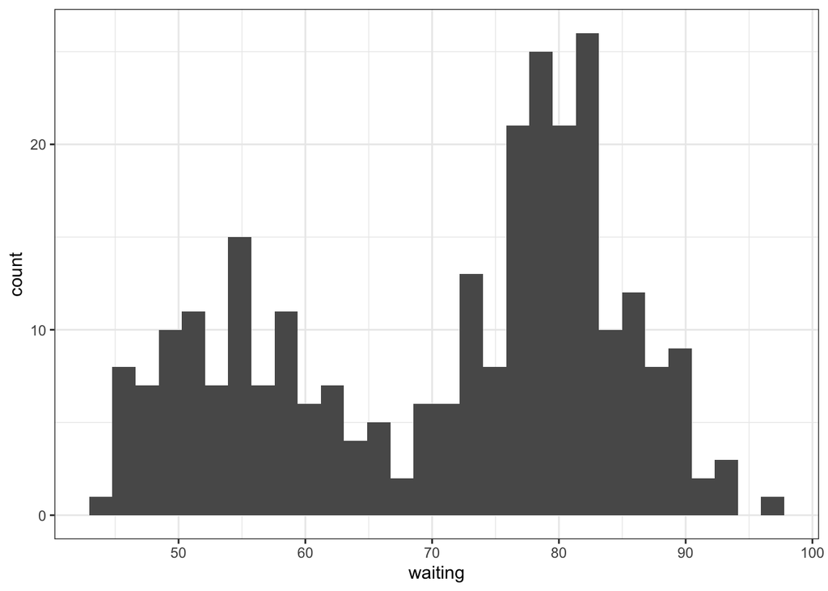

```r
ggplot(faithful, aes(x = waiting)) +
  geom_histogram(bins = 30)
```

On first glance, we seem to see some bimodality, with peaks at around 55 and 80 minutes. Two hypotheses for this:

1. Waiting time is associated with eruption length, and this causes the bimodality.
2. Eruption time is cyclical, and this cycle causes the bimodality.

I don’t know if the data are presented in the order they were collected, so we might not be able to analyse hypothesis 2, but we can check!

First, let’s look at the association between eruption time and waiting time:

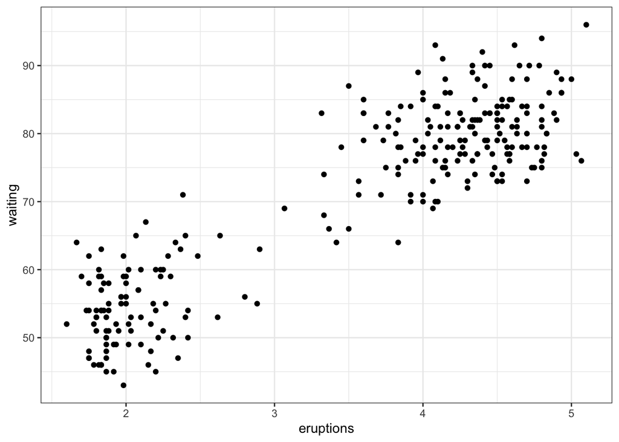

```r
ggplot(faithful, aes(x = eruptions, y = waiting)) +
  geom_point()
```

It certainly looks like the two clusters are a result of eruption time. So if there was a short eruption time, then the subsequent wait time is shorter!

Eruptions are also extremely bimodal:

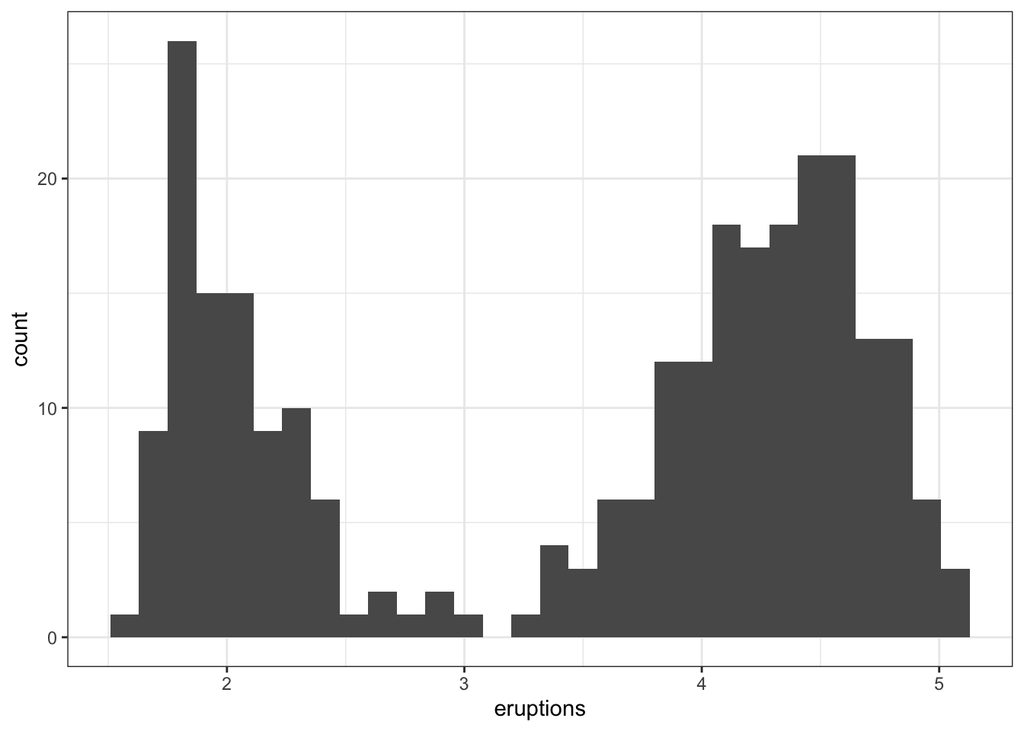

```r
ggplot(faithful, aes(x = eruptions)) +
  geom_histogram(bins = 30)
```

Let’s explore if there is some sort of cycle. There are real statistical methods to do this. But I’ll try to stick to simple methods. First, I plot each eruption time against the next eruption time.

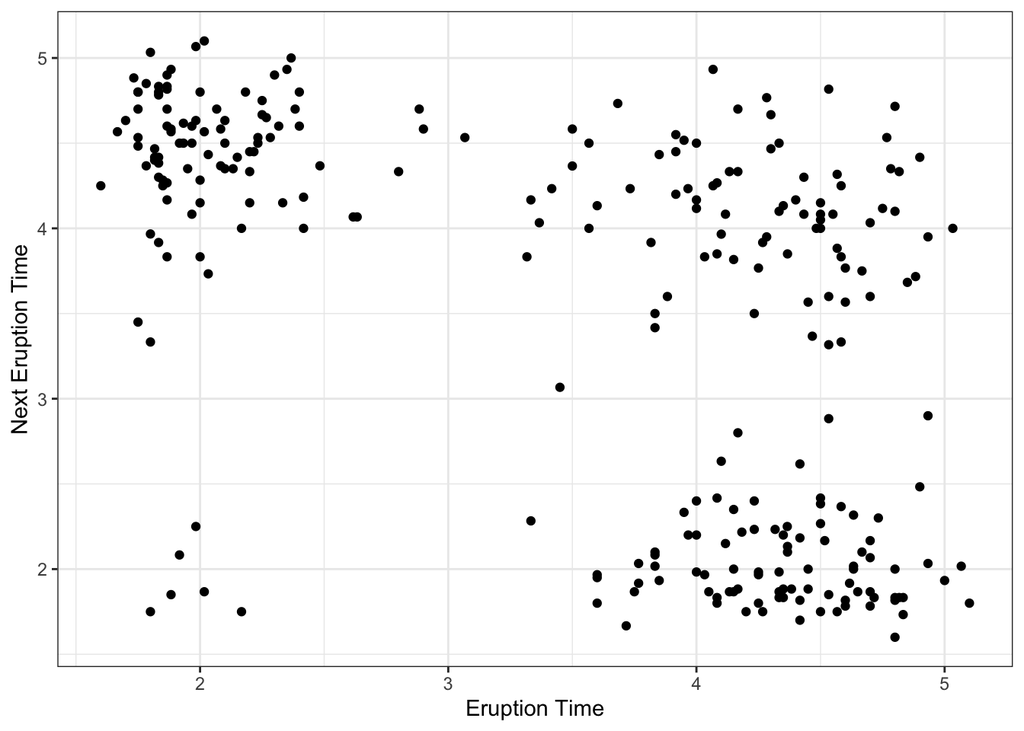

```r
dftemp <- tibble(x = faithful$eruptions[1:(nrow(faithful) - 1)],
                 y = faithful$eruptions[2:nrow(faithful)])
ggplot(dftemp, aes(x = x, y = y)) +
  geom_point() +
  xlab("Eruption Time") +
  ylab("Next Eruption Time")
```

It seems that there are more points in the top left and bottom right quadrants than in the bottom left and top right quadrants, indicating a negative associaiton. Let’s divide the observations into those less than 3 and those greater than 3. This corresponds to “short” and “long” eruptions.

```r
faithful %>%
  mutate(length = case_when(eruptions < 3 ~ "short",
                            eruptions > 3 ~ "long")) ->
  faithful
head(faithful)
```

```
##   eruptions waiting length
## 1     3.600      79   long
## 2     1.800      54  short
## 3     3.333      74   long
## 4     2.283      62  short
## 5     4.533      85   long
## 6     2.883      55  short
```

Let’s look at “transition proportions”: the probability of going to short given long or long given short.

```r
faithful %>%
  mutate(next_length = c(length[2:n()], NA)) ->
  faithful
head(faithful)
```

```
##   eruptions waiting length next_length
## 1     3.600      79   long       short
## 2     1.800      54  short        long
## 3     3.333      74   long       short
## 4     2.283      62  short        long
## 5     4.533      85   long       short
## 6     2.883      55  short        long
```

```r
table(faithful$length, faithful$next_length) %>%
  prop.table(margin = 1)
```

```
##
##               long      short
##   long  0.47701149 0.52298851
##   short 0.93814433 0.06185567
```

So if an eruption is less than 3 minutes, the next eruption has a 93% chance of being greater than 3 minutes. On the other hand if an eruption is greater than 3 minutes, the next eruption only a 52% chance of being less than 3 minutes.

# Conclusion

We found that eruption time and waiting time are very bimodal. This might be partially explained by a cyclical nature of eruptions. For example, we found that after a short eruption (<3 min), there is a 93% chance of there being a long eruption (>3 min). More sophisticated statistical techniques would be needed to more accurately explore this cyclical association.

# References